# $CO_2$ emissions

- Introduction
- Preproessing
- 1. Which countries started recording the 𝐶𝑂2 emissions first and which started last?
- 2. Which countries had the highest and lowest per capita 𝐶𝑂2 emission in latest year (2014)??)
- 3. Which countries have shown the highest increase and decrease in 𝐶𝑂2 emission in the last 5 years (2010-2014)??)
- 4. Trend of per capita CO2 emission of most populous countries

# Introduction

This project analyzes the **$CO_2$ emissions (tonnes per person)** dataset taken from [Gapminder](https://www.gapminder.org/data/).

The dataset contains yearly $CO_2$ emissions from the burning of fossil fuels (metric tonnes of $CO_2$ per person).

# Preproessing

```python
import numpy as np
import pandas as pd
import matplotlib.pyplot as plt
import seaborn as sns
plt.style.use('seaborn')

%matplotlib inline
```

```python
df = pd.read_csv('co2_emissions_tonnes_per_person.csv')
```

```python
df.head()
```

|  | country | 1800 | 1801 | 1802 | 1803 | 1804 | 1805 | 1806 | 1807 | 1808 | ... | 2005 | 2006 | 2007 | 2008 | 2009 | 2010 | 2011 | 2012 | 2013 | 2014 |
| --- | --- | --- | --- | --- | --- | --- | --- | --- | --- | --- | --- | --- | --- | --- | --- | --- | --- | --- | --- | --- | --- |
| 0 | Afghanistan | NaN | NaN | NaN | NaN | NaN | NaN | NaN | NaN | NaN | ... | 0.0529 | 0.0637 | 0.0854 | 0.154 | 0.242 | 0.294 | 0.412 | 0.35 | 0.316 | 0.299 |
| 1 | Albania | NaN | NaN | NaN | NaN | NaN | NaN | NaN | NaN | NaN | ... | 1.3800 | 1.2800 | 1.3000 | 1.460 | 1.480 | 1.560 | 1.790 | 1.68 | 1.730 | 1.960 |
| 2 | Algeria | NaN | NaN | NaN | NaN | NaN | NaN | NaN | NaN | NaN | ... | 3.2200 | 2.9900 | 3.1900 | 3.160 | 3.420 | 3.300 | 3.290 | 3.46 | 3.510 | 3.720 |
| 3 | Andorra | NaN | NaN | NaN | NaN | NaN | NaN | NaN | NaN | NaN | ... | 7.3000 | 6.7500 | 6.5200 | 6.430 | 6.120 | 6.120 | 5.870 | 5.92 | 5.900 | 5.830 |
| 4 | Angola | NaN | NaN | NaN | NaN | NaN | NaN | NaN | NaN | NaN | ... | 0.9800 | 1.1000 | 1.2000 | 1.180 | 1.230 | 1.240 | 1.250 | 1.33 | 1.250 | 1.290 |

5 rows × 216 columns

```python
df.info()
```

```
<class 'pandas.core.frame.DataFrame'>
RangeIndex: 192 entries, 0 to 191
Columns: 216 entries, country to 2014
dtypes: float64(215), object(1)
memory usage: 324.1+ KB
```

```python
df.describe()
```

|  | 1800 | 1801 | 1802 | 1803 | 1804 | 1805 | 1806 | 1807 | 1808 | 1809 | ... | 2005 | 2006 | 2007 | 2008 | 2009 | 2010 | 2011 | 2012 | 2013 | 2014 |
| --- | --- | --- | --- | --- | --- | --- | --- | --- | --- | --- | --- | --- | --- | --- | --- | --- | --- | --- | --- | --- | --- |
| count | 5.000000 | 5.000000 | 7.000000 | 5.000000 | 6.000000 | 5.000000 | 5.000000 | 6.000000 | 5.000000 | 5.000000 | ... | 190.000000 | 190.000000 | 191.000000 | 191.000000 | 191.000000 | 191.000000 | 191.000000 | 192.000000 | 192.000000 | 192.000000 |
| mean | 0.456096 | 0.450782 | 0.620493 | 0.495536 | 0.425787 | 0.510852 | 0.528458 | 0.454672 | 0.516694 | 0.510382 | ... | 4.632572 | 4.696715 | 4.700221 | 4.720091 | 4.506879 | 4.604666 | 4.550413 | 4.526914 | 4.465214 | 4.440085 |
| std | 0.952620 | 0.944430 | 0.994357 | 1.042398 | 0.938020 | 1.056255 | 1.102275 | 0.987935 | 1.075319 | 1.062071 | ... | 6.738075 | 6.943929 | 6.706373 | 6.494926 | 6.157124 | 6.175062 | 6.099754 | 6.145365 | 5.861904 | 6.065368 |
| min | 0.005680 | 0.005610 | 0.005550 | 0.005480 | 0.005420 | 0.005360 | 0.005290 | 0.005230 | 0.005170 | 0.005110 | ... | 0.020800 | 0.024400 | 0.023600 | 0.023200 | 0.022500 | 0.024300 | 0.026800 | 0.030300 | 0.030200 | 0.044500 |
| 25% | 0.034800 | 0.023300 | 0.032500 | 0.023100 | 0.043825 | 0.044500 | 0.040000 | 0.041025 | 0.037900 | 0.039200 | ... | 0.630250 | 0.611500 | 0.595500 | 0.587500 | 0.540500 | 0.607000 | 0.636500 | 0.613750 | 0.669500 | 0.659000 |
| 50% | 0.037200 | 0.038600 | 0.047000 | 0.041200 | 0.046350 | 0.045600 | 0.043700 | 0.050150 | 0.049500 | 0.047700 | ... | 2.140000 | 2.210000 | 2.230000 | 2.340000 | 2.400000 | 2.410000 | 2.410000 | 2.470000 | 2.420000 | 2.265000 |
| 75% | 0.042800 | 0.046400 | 1.047950 | 0.047900 | 0.066800 | 0.058800 | 0.053300 | 0.098425 | 0.050900 | 0.049900 | ... | 6.545000 | 6.425000 | 6.435000 | 6.535000 | 5.865000 | 6.120000 | 6.220000 | 6.100000 | 5.832500 | 5.695000 |
| max | 2.160000 | 2.140000 | 2.130000 | 2.360000 | 2.340000 | 2.400000 | 2.500000 | 2.470000 | 2.440000 | 2.410000 | ... | 58.900000 | 62.800000 | 53.200000 | 46.700000 | 43.500000 | 40.700000 | 41.200000 | 44.600000 | 37.800000 | 45.400000 |

8 rows × 215 columns

```python
# check if any row duplicate
sum(df.duplicated())
```

```
0
```

```python
countries = df['country'].tolist()
year = df.columns.values.tolist()[1:]
print(f'No of countries: {len(countries)}')
print(f'Years: {min(year)}-{max(year)}')
```

```
No of countries: 192
Years: 1800-2014
```

```python
# transpose rows with columns
df = df.T
# make first row as header
df.columns = df.iloc[0]
df = df[1:]
# # change Ist column name
# df.reset_index(level=0, inplace=True)
# df.rename(columns={'index': 'year'}, inplace=True)
```

```python
df.describe()
```

| country | Afghanistan | Albania | Algeria | Andorra | Angola | Antigua and Barbuda | Argentina | Armenia | Australia | Austria | ... | United Kingdom | United States | Uruguay | Uzbekistan | Vanuatu | Venezuela | Vietnam | Yemen | Zambia | Zimbabwe |
| --- | --- | --- | --- | --- | --- | --- | --- | --- | --- | --- | --- | --- | --- | --- | --- | --- | --- | --- | --- | --- | --- |
| count | 66.000 | 82.00 | 105.0 | 25.00 | 65.000 | 58.00 | 128.00 | 163.0 | 164.0 | 197.00 | ... | 215.0 | 215.0 | 83.0 | 163.000 | 53.000 | 104.00 | 114.000 | 65.000 | 51.000 | 98.00 |
| unique | 66.000 | 76.00 | 96.0 | 24.00 | 62.000 | 53.00 | 115.00 | 146.0 | 137.0 | 178.00 | ... | 146.0 | 170.0 | 71.0 | 156.000 | 47.000 | 95.00 | 109.000 | 63.000 | 49.000 | 88.00 |
| top | 0.108 | 1.68 | 0.0 | 6.12 | 0.201 | 3.88 | 1.06 | 1.9 | 0.0 | 7.18 | ... | 11.3 | 19.6 | 2.0 | 0.287 | 0.465 | 6.16 | 0.203 | 0.521 | 0.288 | 1.63 |
| freq | 1.000 | 2.00 | 6.0 | 2.00 | 2.000 | 2.00 | 4.00 | 4.0 | 9.0 | 3.00 | ... | 9.0 | 6.0 | 4.0 | 2.000 | 2.000 | 3.00 | 2.000 | 2.000 | 2.000 | 3.00 |

4 rows × 192 columns

As is evident from the above result of `.describe`, not all the countries have emissions recoreded for every year.

```python
# replace NaN with 0s
df.fillna(0, inplace=True)
```

```python
df.head()
```

| country | Afghanistan | Albania | Algeria | Andorra | Angola | Antigua and Barbuda | Argentina | Armenia | Australia | Austria | ... | United Kingdom | United States | Uruguay | Uzbekistan | Vanuatu | Venezuela | Vietnam | Yemen | Zambia | Zimbabwe |
| --- | --- | --- | --- | --- | --- | --- | --- | --- | --- | --- | --- | --- | --- | --- | --- | --- | --- | --- | --- | --- | --- |
| 1800 | 0.0 | 0.0 | 0.0 | 0.0 | 0.0 | 0.0 | 0.0 | 0.0 | 0.0 | 0.0 | ... | 2.16 | 0.0372 | 0.0 | 0.0 | 0.0 | 0.0 | 0.0 | 0.0 | 0.0 | 0.0 |
| 1801 | 0.0 | 0.0 | 0.0 | 0.0 | 0.0 | 0.0 | 0.0 | 0.0 | 0.0 | 0.0 | ... | 2.14 | 0.0386 | 0.0 | 0.0 | 0.0 | 0.0 | 0.0 | 0.0 | 0.0 | 0.0 |
| 1802 | 0.0 | 0.0 | 0.0 | 0.0 | 0.0 | 0.0 | 0.0 | 0.0 | 0.0 | 0.0 | ... | 2.13 | 0.0410 | 0.0 | 0.0 | 0.0 | 0.0 | 0.0 | 0.0 | 0.0 | 0.0 |
| 1803 | 0.0 | 0.0 | 0.0 | 0.0 | 0.0 | 0.0 | 0.0 | 0.0 | 0.0 | 0.0 | ... | 2.36 | 0.0412 | 0.0 | 0.0 | 0.0 | 0.0 | 0.0 | 0.0 | 0.0 | 0.0 |
| 1804 | 0.0 | 0.0 | 0.0 | 0.0 | 0.0 | 0.0 | 0.0 | 0.0 | 0.0 | 0.0 | ... | 2.34 | 0.0454 | 0.0 | 0.0 | 0.0 | 0.0 | 0.0 | 0.0 | 0.0 | 0.0 |

5 rows × 192 columns

## 1. Which countries started recording the $CO_2$ emissions first and which started last?

```python
# get first non-zero value in each column corresponding to rows
min_pair = df.ne(0).idxmax()
min_pair
```

```
country
Afghanistan    1949
Albania        1933
Algeria        1916
Andorra        1990
Angola         1950
               ...
Venezuela      1904
Vietnam        1892
Yemen          1950
Zambia         1964
Zimbabwe       1903
Length: 192, dtype: object
```

```python
# min year
min_pair[min_pair == min_pair.min()]
```

```
country
Canada            1800
Germany           1800
Poland            1800
United Kingdom    1800
United States     1800
dtype: object
```

```python
# max year
min_pair[min_pair == min_pair.max()]
```

```
country
South Sudan    2012
dtype: object
```

**Conclusion:**  
Thus, Canada, Germany, Poland, United Kingdom, and United States started recording CO2 emissions from year 1800, while South Sudan only started recording in 2012.

# 2. Which countries had the highest and lowest per capita $CO_2$ emission in latest year (2014)?

```python
# get top 10 values for year 2014
top10 = df.iloc[-1].sort_values(ascending=False)[:10]
top10
```

```
country
Qatar                   45.4
Trinidad and Tobago     34.2
Kuwait                  25.2
Bahrain                 23.4
United Arab Emirates    23.3
Brunei                  22.1
Saudi Arabia            19.5
Luxembourg              17.4
United States           16.5
Oman                    15.4
Name: 2014, dtype: float64
```

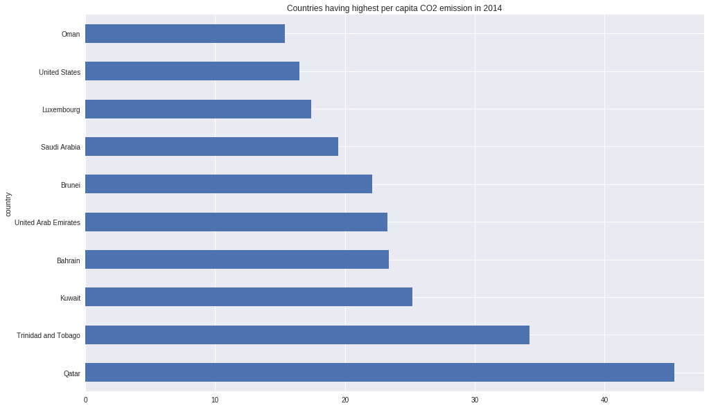

```python
top10.plot(kind='barh', figsize=(16, 10), title='Countries having highest per capita CO2 emission in 2014')
```

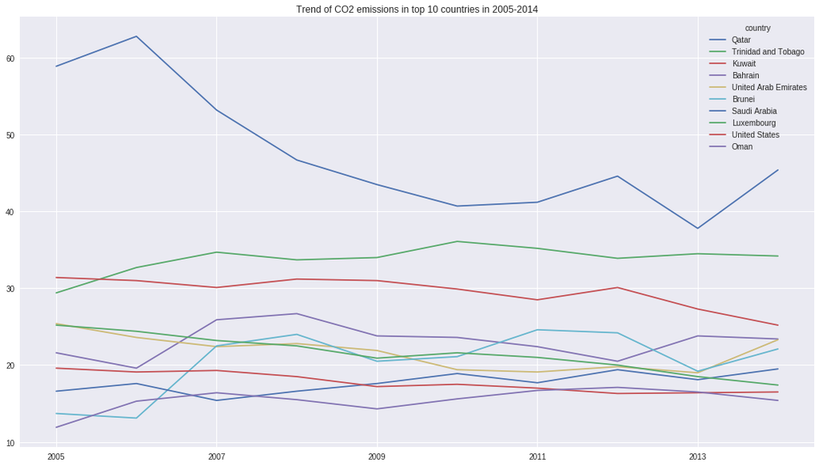

```python
# CO2 emission of top 10 countries in the last 10 years
df[top10.keys().tolist()][-10:].plot(figsize=(16, 10), title='Trend of CO2 emissions in top 10 countries in 2005-2014')
```

```python
# get bottom 10 values for year 2014
bottom10 = df.iloc[-1].sort_values(ascending=True)[:10]
bottom10
```

```
country
Burundi                     0.0445
Somalia                     0.0450
Chad                        0.0538
Congo, Dem. Rep.            0.0634
Central African Republic    0.0666
Rwanda                      0.0740
Malawi                      0.0748
Mali                        0.0832
Niger                       0.1110
Ethiopia                    0.1190
Name: 2014, dtype: float64
```

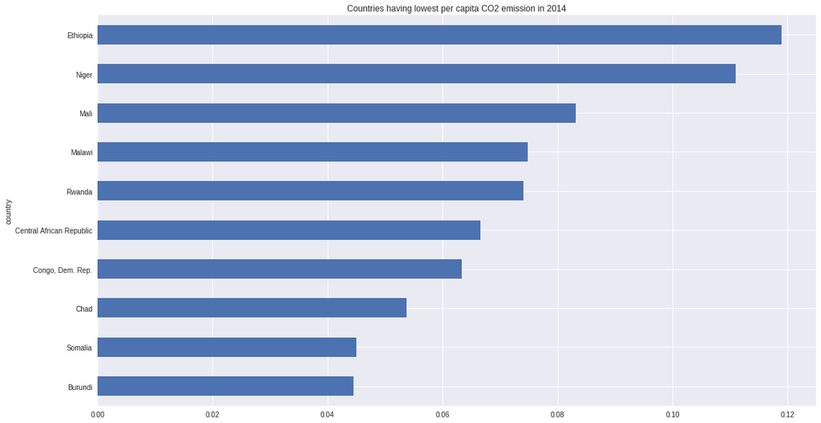

```python
bottom10.plot(kind='barh', figsize=(16, 10), title='Countries having lowest per capita CO2 emission in 2014')
```

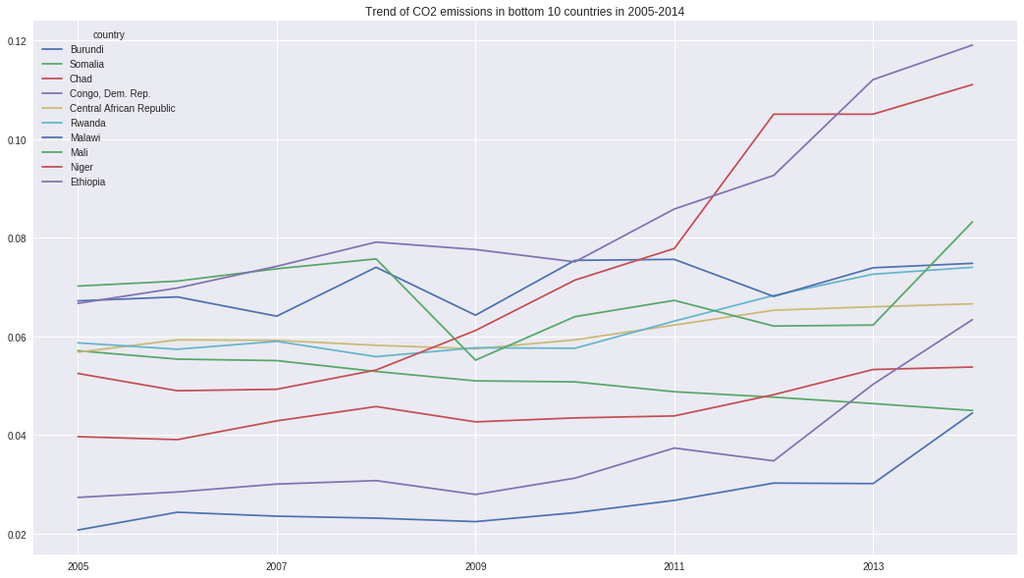

```python
# CO2 emission of bottom 10 countries in the last 10 years
df[bottom10.keys().tolist()][-10:].plot(figsize=(16, 10), title='Trend of CO2 emissions in bottom 10 countries in 2005-2014')
```

```python
# percentage of CO2 emission in 2014
emission_2014 = df.iloc[-1].sort_values(ascending=False)
percent = emission_2014/sum(emission_2014)*100
```

```python
# group CO2 emissions less than 1% into 'rest' category
percent_threshold = percent[percent > 0.7]
percent_threshold['rest'] = percent[percent <= 0.7].sum()
```

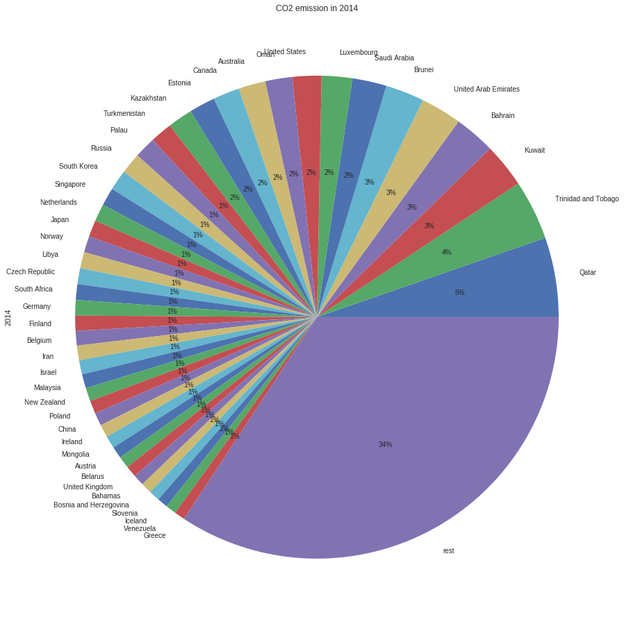

```python
percent_threshold.plot(kind='pie', figsize=(16, 16), autopct='%1.0f%%', title='CO2 emission in 2014')
```

**Conclusion:**

Countries having maximum per capita $CO_2$ emission in 2014: Qatar, Trinidad and Tobago, Kuwait  
Countries having minimum per capita $CO_2$ emission in 2014: Burundi, Somalia, Chad

# 3. Which countries have shown the highest increase and decrease in $CO_2$ emission in the last 5 years (2010-2014)?

```python
df.iloc[-5:].T.sort_values(by='2014', ascending=False).style.background_gradient('Reds', subset=['2014','2012', '2010'])\
.background_gradient(cmap="Blues", subset=['2013', '2011'])
```

| country | 2010 | 2011 | 2012 | 2013 | 2014 |
| --- | --- | --- | --- | --- | --- |
| Qatar | 40.700000 | 41.200000 | 44.600000 | 37.800000 | 45.400000 |
| Trinidad and Tobago | 36.100000 | 35.200000 | 33.900000 | 34.500000 | 34.200000 |
| Kuwait | 29.900000 | 28.500000 | 30.100000 | 27.300000 | 25.200000 |
| Bahrain | 23.600000 | 22.400000 | 20.500000 | 23.800000 | 23.400000 |
| United Arab Emirates | 19.400000 | 19.100000 | 19.800000 | 19.000000 | 23.300000 |
| Brunei | 21.100000 | 24.600000 | 24.200000 | 19.200000 | 22.100000 |
| Saudi Arabia | 18.900000 | 17.700000 | 19.400000 | 18.100000 | 19.500000 |
| Luxembourg | 21.600000 | 21.000000 | 20.000000 | 18.500000 | 17.400000 |
| United States | 17.500000 | 17.000000 | 16.300000 | 16.400000 | 16.500000 |
| Australia | 17.700000 | 17.400000 | 17.000000 | 16.100000 | 15.400000 |
| Oman | 15.600000 | 16.700000 | 17.100000 | 16.500000 | 15.400000 |
| Canada | 15.600000 | 15.600000 | 14.800000 | 14.700000 | 15.100000 |
| Estonia | 13.600000 | 14.000000 | 13.300000 | 15.100000 | 14.800000 |
| Kazakhstan | 15.200000 | 15.600000 | 14.400000 | 15.300000 | 14.200000 |
| Turkmenistan | 11.300000 | 12.100000 | 12.300000 | 12.400000 | 12.500000 |
| Palau | 12.400000 | 12.300000 | 12.200000 | 12.300000 | 12.300000 |
| Russia | 11.700000 | 12.300000 | 12.800000 | 12.400000 | 11.900000 |
| South Korea | 11.400000 | 11.800000 | 11.700000 | 11.800000 | 11.700000 |
| Singapore | 11.000000 | 8.740000 | 6.900000 | 10.400000 | 10.300000 |
| Netherlands | 11.000000 | 10.400000 | 10.100000 | 10.300000 | 9.910000 |
| Japan | 9.110000 | 9.270000 | 9.580000 | 9.710000 | 9.470000 |
| Norway | 12.300000 | 9.130000 | 9.950000 | 11.500000 | 9.270000 |
| Libya | 10.000000 | 6.410000 | 8.500000 | 9.080000 | 9.190000 |
| Czech Republic | 10.600000 | 10.100000 | 9.540000 | 9.310000 | 9.100000 |
| South Africa | 9.190000 | 9.000000 | 8.850000 | 8.670000 | 8.980000 |
| Germany | 9.380000 | 9.050000 | 9.130000 | 9.320000 | 8.830000 |
| Finland | 11.600000 | 10.500000 | 9.080000 | 8.690000 | 8.660000 |
| Belgium | 10.100000 | 9.080000 | 8.580000 | 8.700000 | 8.320000 |
| Iran | 7.680000 | 7.800000 | 8.000000 | 8.000000 | 8.280000 |
| Israel | 9.280000 | 9.130000 | 9.810000 | 8.580000 | 8.130000 |

[output cut: 162 more lines]

```python
# CO2 emissions in last 5 years
df.iloc[-5:].style.background_gradient(cmap='Reds')
```

| country | Afghanistan | Albania | Algeria | Andorra | Angola | Antigua and Barbuda | Argentina | Armenia | Australia | Austria | Azerbaijan | Bahamas | Bahrain | Bangladesh | Barbados | Belarus | Belgium | Belize | Benin | Bhutan | Bolivia | Bosnia and Herzegovina | Botswana | Brazil | Brunei | Bulgaria | Burkina Faso | Burundi | Cambodia | … |
| --- | --- | --- | --- | --- | --- | --- | --- | --- | --- | --- | --- | --- | --- | --- | --- | --- | --- | --- | --- | --- | --- | --- | --- | --- | --- | --- | --- | --- | --- | --- |
| 2010 | 0.294000 | 1.560000 | 3.300000 | 6.120000 | 1.240000 | 5.540000 | 4.560000 | 1.470000 | 17.700000 | 8.030000 | 3.400000 | 4.580000 | 23.600000 | 0.394000 | 5.290000 | 6.650000 | 10.100000 | 1.680000 | 0.553000 | 0.670000 | 1.530000 | 5.720000 | 2.330000 | 2.130000 | 21.100000 | 5.960000 | 0.126000 | 0.024300 | 0.350000 | … |
| 2011 | 0.412000 | 1.790000 | 3.290000 | 5.870000 | 1.250000 | 5.360000 | 4.600000 | 1.710000 | 17.400000 | 7.690000 | 3.660000 | 5.090000 | 22.400000 | 0.412000 | 5.450000 | 6.770000 | 9.080000 | 1.830000 | 0.560000 | 0.990000 | 1.600000 | 6.480000 | 2.040000 | 2.210000 | 24.600000 | 6.710000 | 0.138000 | 0.026800 | 0.358000 | … |
| 2012 | 0.350000 | 1.680000 | 3.460000 | 5.920000 | 1.330000 | 5.420000 | 4.570000 | 1.980000 | 17.000000 | 7.310000 | 3.840000 | 5.290000 | 20.500000 | 0.433000 | 5.220000 | 6.670000 | 8.580000 | 1.420000 | 0.562000 | 1.090000 | 1.840000 | 6.100000 | 2.030000 | 2.340000 | 24.200000 | 6.120000 | 0.159000 | 0.030300 | 0.369000 | … |
| 2013 | 0.316000 | 1.730000 | 3.510000 | 5.900000 | 1.250000 | 5.360000 | 4.460000 | 1.900000 | 16.100000 | 7.280000 | 3.800000 | 7.430000 | 23.800000 | 0.442000 | 5.130000 | 6.730000 | 8.700000 | 1.490000 | 0.581000 | 1.200000 | 1.820000 | 6.080000 | 2.460000 | 2.490000 | 19.200000 | 5.450000 | 0.179000 | 0.030200 | 0.373000 | … |
| 2014 | 0.299000 | 1.960000 | 3.720000 | 5.830000 | 1.290000 | 5.380000 | 4.750000 | 1.900000 | 15.400000 | 6.800000 | 3.940000 | 6.320000 | 23.400000 | 0.459000 | 4.490000 | 6.690000 | 8.320000 | 1.410000 | 0.614000 | 1.290000 | 1.930000 | 6.230000 | 3.240000 | 2.590000 | 22.100000 | 5.870000 | 0.162000 | 0.044500 | 0.438000 | … |

```python
# change from the year in which cases were reported for all countries: 2012
change = df.iloc[[-5, -1]]
change
```

| country | Afghanistan | Albania | Algeria | Andorra | Angola | Antigua and Barbuda | Argentina | Armenia | Australia | Austria | ... | United Kingdom | United States | Uruguay | Uzbekistan | Vanuatu | Venezuela | Vietnam | Yemen | Zambia | Zimbabwe |
| --- | --- | --- | --- | --- | --- | --- | --- | --- | --- | --- | --- | --- | --- | --- | --- | --- | --- | --- | --- | --- | --- |
| 2010 | 0.294 | 1.56 | 3.30 | 6.12 | 1.24 | 5.54 | 4.56 | 1.47 | 17.7 | 8.03 | ... | 7.79 | 17.5 | 1.89 | 3.64 | 0.512 | 6.51 | 1.61 | 0.993 | 0.194 | 0.552 |
| 2014 | 0.299 | 1.96 | 3.72 | 5.83 | 1.29 | 5.38 | 4.75 | 1.90 | 15.4 | 6.80 | ... | 6.46 | 16.5 | 1.97 | 3.45 | 0.595 | 6.03 | 1.80 | 0.865 | 0.288 | 0.780 |

2 rows × 192 columns

```python
# append difference row
diff = df.iloc[-1] - df.iloc[-5]
diff.name = 'diff'
change = change.append(diff)
```

```python
def color_negative_red(val):
    """
    Takes a scalar and returns a string with
    the css property `'color: green'` for negative
    strings, red otherwise.
    """
    color = 'green' if val < 0 else 'red'
    return 'background-color: %s' % color
```

```python
# CO2 emission decrease shown in green, increase shown in red
change.style.applymap(color_negative_red, subset=pd.IndexSlice['diff',])
```

| country | Afghanistan | Albania | Algeria | Andorra | Angola | Antigua and Barbuda | Argentina | Armenia | Australia | Austria | Azerbaijan | Bahamas | Bahrain | Bangladesh | Barbados | Belarus | Belgium | Belize | Benin | Bhutan | Bolivia | Bosnia and Herzegovina | Botswana | Brazil | Brunei | Bulgaria | Burkina Faso | Burundi | Cambodia | … |
| --- | --- | --- | --- | --- | --- | --- | --- | --- | --- | --- | --- | --- | --- | --- | --- | --- | --- | --- | --- | --- | --- | --- | --- | --- | --- | --- | --- | --- | --- | --- |
| 2010 | 0.294000 | 1.560000 | 3.300000 | 6.120000 | 1.240000 | 5.540000 | 4.560000 | 1.470000 | 17.700000 | 8.030000 | 3.400000 | 4.580000 | 23.600000 | 0.394000 | 5.290000 | 6.650000 | 10.100000 | 1.680000 | 0.553000 | 0.670000 | 1.530000 | 5.720000 | 2.330000 | 2.130000 | 21.100000 | 5.960000 | 0.126000 | 0.024300 | 0.350000 | … |
| 2014 | 0.299000 | 1.960000 | 3.720000 | 5.830000 | 1.290000 | 5.380000 | 4.750000 | 1.900000 | 15.400000 | 6.800000 | 3.940000 | 6.320000 | 23.400000 | 0.459000 | 4.490000 | 6.690000 | 8.320000 | 1.410000 | 0.614000 | 1.290000 | 1.930000 | 6.230000 | 3.240000 | 2.590000 | 22.100000 | 5.870000 | 0.162000 | 0.044500 | 0.438000 | … |
| diff | 0.005000 | 0.400000 | 0.420000 | -0.290000 | 0.050000 | -0.160000 | 0.190000 | 0.430000 | -2.300000 | -1.230000 | 0.540000 | 1.740000 | -0.200000 | 0.065000 | -0.800000 | 0.040000 | -1.780000 | -0.270000 | 0.061000 | 0.620000 | 0.400000 | 0.510000 | 0.910000 | 0.460000 | 1.000000 | -0.090000 | 0.036000 | 0.020200 | 0.088000 | … |

```python
# change in CO2 emissions
max_change = change.iloc[-1].sort_values()
max_change
```

```
country
Kuwait                 -4.70
Luxembourg             -4.20
Norway                 -3.03
Finland                -2.94
Denmark                -2.49
                        ...
Estonia                 1.20
Bahamas                 1.74
Mongolia                2.04
United Arab Emirates    3.90
Qatar                   4.70
Name: diff, Length: 192, dtype: float64
```

# 4. Trend of per capita CO2 emission of most populous countries

```python
# top populous countries
population = ['China', 'India', 'United States', 'Indonesia', 'Brazil', 'Pakistan']
```

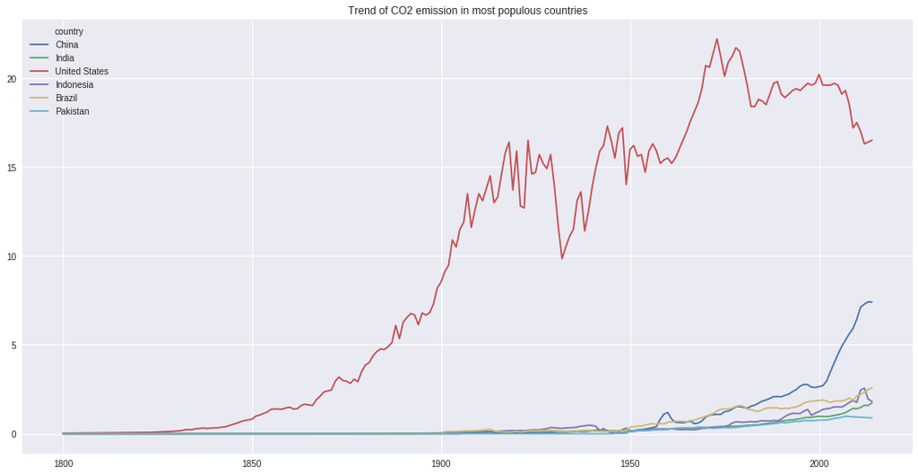

```python
df[population].plot(figsize=(16, 9), title='Trend of CO2 emission in most populous countries')
```

**Conclusion:**

United States has far greater per captia $CO_2$ emission compared to other populous countries. It can also be noted that China has also shown a steep rise since 2000.